# PerfectPup, CS 4300 (Language and Information)

## Dog Breed Data Set Exploration

[figure not shown]

Since we are creating a information retrieval system that will allow users to query dog characteristics, personalities, specificities, etc.. and return a list of the most relevant dog breeds, we are choosing to use data that was harvested from the American Kennel Club website, a registry of purebreed dog pedigrees (which happens to promote/sanction the Westminster Kennel Club Dog Show, one of, if not, the most famous and oldest dog shows!), that describes various characteristics and data for 277 different dog breeds. There are roughly 340 to 360 recognized dog breeds in total, so this collection of 277 breeds represents, on the lower bound ~77%, and on the upperbound ~81%, off all dog breeds, so there is a healthy representation. Because of this, we do not plan on acquiring more data, as missing breeds could potentially be ones that are not universally recognized or rare/niche. This dataset includes information such as description, height, weight, personality, popularity, and a lot more, which will allow users to query on a rich and expressive set of parameters they could be looking for in a dog breed. We will be exploring this data by finding the distribution and analyzing some of the statistics for a variety of these characteristics. At this time we do not plan to use a supervised ML approach. All credit goes to Telmo Filho, of the University of Bristol, for scraping this data off the AKC website using BeautifulSoup.

## Imports and Initial Observations

```python
import pandas as pd
import matplotlib.pyplot as plt

dog_data = pd.read_csv("akc-data-latest.csv")

# Data Cleaning
dog_data['popularity'] = dog_data['popularity'].fillna(1000)
dog_data['popularity'] = dog_data['popularity'].replace("of", 1000)
```

Our data is in the .csv format, so let's see how it looks llike as a "spreadsheet". Note, the column "Unnamed: 0" is the name of our dog breeds.

```python
dog_data.head()
```

|  | Unnamed: 0 | description | temperament | popularity | min_height | max_height | min_weight | max_weight | min_expectancy | max_expectancy | ... | grooming_frequency_value | grooming_frequency_category | shedding_value | shedding_category | energy_level_value | energy_level_category | trainability_value | trainability_category | demeanor_value | demeanor_category |
| --- | --- | --- | --- | --- | --- | --- | --- | --- | --- | --- | --- | --- | --- | --- | --- | --- | --- | --- | --- | --- | --- |
| 0 | Affenpinscher | The Affen’s apish look has been described many... | Confident, Famously Funny, Fearless | 148 | 22.86 | 29.21 | 3.175147 | 4.535924 | 12.0 | 15.0 | ... | 0.6 | 2-3 Times a Week Brushing | 0.6 | Seasonal | 0.6 | Regular Exercise | 0.8 | Easy Training | 1.0 | Outgoing |
| 1 | Afghan Hound | The Afghan Hound is an ancient breed, his whol... | Dignified, Profoundly Loyal, Aristocratic | 113 | 63.50 | 68.58 | 22.679619 | 27.215542 | 12.0 | 15.0 | ... | 0.8 | Daily Brushing | 0.2 | Infrequent | 0.8 | Energetic | 0.2 | May be Stubborn | 0.2 | Aloof/Wary |
| 2 | Airedale Terrier | The Airedale Terrier is the largest of all ter... | Friendly, Clever, Courageous | 60 | 58.42 | 58.42 | 22.679619 | 31.751466 | 11.0 | 14.0 | ... | 0.6 | 2-3 Times a Week Brushing | 0.4 | Occasional | 0.6 | Regular Exercise | 1.0 | Eager to Please | 0.8 | Friendly |
| 3 | Akita | Akitas are burly, heavy-boned spitz-type dogs ... | Courageous, Dignified, Profoundly Loyal | 47 | 60.96 | 71.12 | 31.751466 | 58.967008 | 10.0 | 13.0 | ... | 0.8 | Daily Brushing | 0.6 | Seasonal | 0.8 | Energetic | 1.0 | Eager to Please | 0.6 | Alert/Responsive |
| 4 | Alaskan Malamute | The Alaskan Malamute stands 23 to 25 inches at... | Affectionate, Loyal, Playful | 58 | 58.42 | 63.50 | 34.019428 | 38.555351 | 10.0 | 14.0 | ... | 0.6 | 2-3 Times a Week Brushing | 0.6 | Seasonal | 0.8 | Energetic | 0.4 | Independent | 0.8 | Friendly |

5 rows × 21 columns

From this, we can see that the data we have to play with is the dog breed name itself, a description, temperament / personality traits, popularity, height, weight, life expectancy, groomy frequency, shedding frequency, energy levels, trainability, and demeanor. This gives us quite a rich data set that includes almost every factor that one would consider when trying to choose a dog breed, giving us a lot of power how we analyze the users query when determing our most relevant results.

Let's confirm that there are 277 breeds.

```python
print("There are " + str(len(dog_data["Unnamed: 0"])) + " different dog breeds in this data set.")
```

```
There are 277 different dog breeds in this data set.
```

Let's take a look at the top 10 most popular breeds!

```python
breed_popularity = []
for idx in range(277):
    breed_popularity.append((float(dog_data["popularity"][idx]),dog_data["Unnamed: 0"][idx]))

breed_popularity = sorted(breed_popularity, key= lambda bd: bd[0])

for idx in range(12):
    print(breed_popularity[idx][1] + " " + str(breed_popularity[idx][0]))
```

```
Labrador Retriever 1.0
German Shepherd Dog 2.0
Golden Retriever 3.0
French Bulldog 4.0
Bulldog 5.0
Beagle 6.0
Poodle (Miniature) 7.0
Poodle (Standard) 7.0
Poodle (Toy) 7.0
Rottweiler 8.0
German Shorthaired Pointer 9.0
Yorkshire Terrier 10.0
```

Unfortunately, while the AKC has information on many dog breeds, they only recognize 200 dog breeds (as purebred) as of 2023, with only 195 recognized in 2020 when this data was harvested. For some reason, (what I'm assuming to be scraping errors), some recognized dogs in 2020 have a popularity value of "of", which means they also cannot be ranked. As a result, many dog breeds cannot be assigned a popularity score. It may be possible to reconstruct this list in our information retreival system to be more up to date and accurate, however. From this list we can see that many of the breeds that are universally recognizable, such as Poodles, Golden Retrievers, and Bulldogs, are present on this list! Popularity is an interesting social measure, and this top ten seems to line up with what I would expect with purebred dogs.

For fun, let's take a look at the top 10 least popular breeds as well.

```python
for idx in range(185,195):
    print(breed_popularity[idx][1] + " " + str(breed_popularity[idx][0]))
```

```
Cirneco dell’Etna 183.0
Finnish Spitz 184.0
Cesky Terrier 185.0
American Foxhound 186.0
Bergamasco Sheepdog 187.0
English Foxhound 188.0
Harrier 189.0
Chinook 190.0
Norwegian Lundehund 191.0
Sloughi 192.0
```

Personally, I have never heard of these breeds, so this is probably accurate.

With that out of the way, let's start to do some real analysis of this data.

## Distributions of a Variety of Characteristics

Something important that we should do is analyze how well our data is distributed across values. A weak distribution would imply a large similarity across all our breeds. In this case, it would not be a very interesting or useful data set, and therefore project, if all the dog breeds we were dealing with were practically the same. This will give us a good idea of how many different possibilities and cominbations of traits there are and how expressive this data set can be against a wide range of queries.

### Demeanor Analysis

From our data set, demeanor is defined as "A categorization of reaction to strangers and other pets", which seems like a pretty useful metric to include. Some people have children, like to take their dog out and around, or have frequent guests, so knowing how a dog breed typical reacts around others is an important characteristic. Let's see what different kinds of demeanors AKC thinks dogs can have.

```python
demeanors = list(set(list(dog_data["demeanor_category"])))
print(demeanors)
```

```
[nan, 'Friendly', 'Outgoing', 'Alert/Responsive', 'Reserved with Strangers', 'Aloof/Wary']
```

It looks like dogs can be "Aloof/Wary", "Friendly", "Alert/Responsive", "Reserved with Strangers", and "Outgoing" based on some kind of a 1-5 scale. Considering this is a hard characteristic to objectively measure, the AKC does a good job creating 5 different distinctions such that one can defintely tell the difference between an "Outgoing" dog breed and one that is "Reserved with Strangers". Unfortunately, once again, it seems like due to data collection issues, some dog breeds were not assigned a demeanor category, which may or may not pose an issue in the final product. Let's see how many dog breeds this will be an issue for.

```python
nan_counts = ["nan" for demeanor in (list(dog_data["demeanor_category"])) if pd.isna(demeanor)]
print("There are " + str(len(nan_counts)) + " dog breed with NaN values for their demenaor category.")
```

```
There are 25 dog breed with NaN values for their demenaor category.
```

For most dogs, this missing value will not be an issue. For the 25 breeds who are missing it, many, if not all of, the values in their other columns of the csv are not empty, which will still give us plenty of characteristics that we can query against, even if it is incomplete. Let's analyze the distribution now.

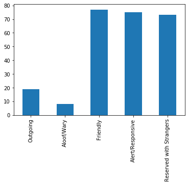

```python
demeanor_counts = [demeanor for demeanor in (list(dog_data["demeanor_category"])) if demeanor != "nan"]
pd.Series(demeanor_counts).value_counts(sort=False).plot(kind='bar')
```

This graph shows us some pretty interesting results, but none unexpected. Among the demeanor categories "Friendly", "Alert/Responsive", and "Reserved with Strangers", there was a roughly equal frequency of them at around ~70-80 dog breeds in each category. These three categories comprise the vast majority of dog breeds in our data set. Although our graph is un-ordered, these three categories also represent the three less extreme demeanor categories on both ends, so it makes sense that most dog breeds would fall in the milder range of demeanors. This is also a good sign because it shows that our data is distributed relatively well across the mean, allowing for many options among the most common / less extreme demeanors, which most people are probably seeking. About 7% of dogs were rated "Outgoing", and < 4% were rated "Aloof/Wary", the two extremes of our demeanor categories. Intuitively, this makes sense, as dogs are considered "man's best friend", so it would be odd if there was a significant amount of them that did not play nice with other humans. As for the outgoing dog breeds, there is enough of them that provide a good range of options while maintaing their own category of hyper-friendliness for those who seek a dog breed of that kind. Since these two extremes represent < 10% of the dog breeds in our data set total, this is also a good sign showing a relatively even distribution.

Let's now try to analyze the distribution of some characteristics that are not as discrete or subjective as demeanor...

### Weight Analysis

Our data set contains the `max_weight` and `min_weight` in kilograms for our set of 277 dog breeds. Like demeanor, this is also a very important attribute to consider because of the many deciding factors there are when choosing a dog breed, size is definitely a deal breaker. Weight is a generally good metric for dog size as larger dogs will simply weigh more, and the ranges of dog weights is very wide. Let's see what the range is in our data set.

```python
min_weights = list(dog_data["min_weight"])
min_weights = [weight for weight in min_weights if weight != 0.0]
min_weights = [weight for weight in min_weights if pd.notna(weight)]
max_weights = list(dog_data["min_weight"])
max_weights = [weight for weight in min_weights if pd.notna(weight)]

print("The lightest dog in our data set can have a minimum weight of " + str(min(min_weights)) + " kilograms and the heaviest dog in our data set can have a maximum weight of " + str(max(max_weights)) + "kilograms.")
```

[output not shown]

As we can see, dog weights vary extremely, with our lightest small dog breed weighing ~1.36 kg and our heaviest heavy dog breed weighing ~68 kg. Again, due to data collection issues some dogs either have no weights or a weight of 0. Let's see how many are impacted.

```python
err_min_weights = list(dog_data["min_weight"])
err_min_weights = [weight for weight in err_min_weights if float(weight) == 0.0 or pd.isna(weight)]

print("There are " + str(len(err_min_weights)) + " dog breeds with problematic weight values." )
```

```
There are 3 dog breeds with problematic weight values.
```

A very insignificant number of dog breeds have problematic entries for their weights, so in our final product, this will largely be a non-issue. These dogs have other data for the other characteristics properly filled in that will allow them to be queried. It would also not be much work to manually find and fill in the minmum and maximum weight for these dog breeds. Let's now analyze the distribution our dog weights. In order to do so, we will find the rough average weight of our dog breed and group them into "Small", "Medium", "Large", and "Giant" according to some rough consensus online about dog sizes.

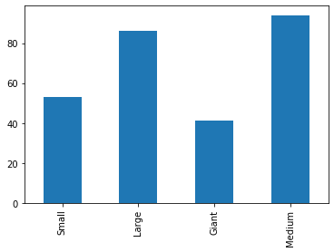

```python
average_weight = [w1+w2/2 for w1,w2 in zip(min_weights,max_weights)]

size_counts = []
for idx in range(len(average_weight)):
    if average_weight[idx] <= 10:
        size_counts.append("Small")
    elif average_weight[idx] > 10 and average_weight[idx] <= 26:
        size_counts.append("Medium")
    elif average_weight[idx] > 26 and average_weight[idx] <= 45:
        size_counts.append("Large")
    else:
        size_counts.append("Giant")

pd.Series(size_counts).value_counts(sort=False).plot(kind='bar')
```

Once again, this graph shows some really promising results for our distribution! Our extreme values, "Small" and "Giant" are slightly less frequent than our more middle values "Medium" and "Large", but overall, every size category is well represented, with the smallest being "Giant" with still at least 40 dog breeds represented. As the largest category, "Medium" represents slightly under 100 dog breeds, and slightly out dominates the "Large" category, which makes sense because the majority of dog breeds will be medium sized, i.e. right in the middle. Overall, there is a large and distributed variety of dog breed sizes that our information retrieval system has to choose from, providing a wide variety of dogs to further choose from according to the users query!

Finally, let's one more interesting one for fun.

### Temperament / Personality Analysis

Dogs are like humans in that they each have their own unique personality, which is what makes them so lovable! They are like tiny human compansions that can't speak, but are extremely loyal. While all dogs are different, the AKC has provided a temperament category which is a general descriptor for this dog breed's personality. This is an important metric to include because people will generally use similar adjectives that the AKC uses to describe dogs in their queries describing the dog breed they want. We imagine this column may do a lot of heavy lifting when it comes to information retrieval as a result, so it would be good to analyze it now.

```python
temperaments = list(dog_data["temperament"])
err_traits = [temperament for temperament in temperaments if pd.isna(temperament)]
temperaments = [temperament for temperament in temperaments if pd.notna(temperament)]


def tokenize(str):
    return str.split(",")

personality_traits = [tokenize(traits) for traits in temperaments]
personality_traits = [trait for traits in personality_traits for trait in traits]

print("There are " + str(len(set(personality_traits))) + " different personality traits." )
print("There is " + str(len(err_traits)) + " breed with problematic personality trait entries." )
```

```
There are 177 different personality traits.
There is 1 breed with problematic personality trait entries.
```

Wow! That is a lot of different personality traits, nearly as many as there are dogs. Thankfully, this gives us **many** different personality traits to query against, and from the data set we can see that most dogs have at least 3 personality traits, allowing for powerful searchability for every dog breed. The fact that there are that many unique personality traits means that most dog breeds have their own unique set personality traits, and there is not much overlap in dog breed personalities. Since there are only so many different adjectives one can use to describe a dog breed, this would suggest that many queries will have a uniquely top result that is very relevant, which for our purposes is a good thing, since most people are not looking to adopt multiple dog breeds at one time. They are really only looking for a top choice. Since there is also only 1 dog breed with a problematic personality trait entry, this will also be a non-problem. Unfortunately, this dog breed may not show up in many queries, however, after further inspection it seems that it is a rather niche / uncommon dog breed anyway. Let's now try to analyze the distribution of these personality traits.

```
There are 35 personality traits that are used for at least 7 different dog breeds.
```

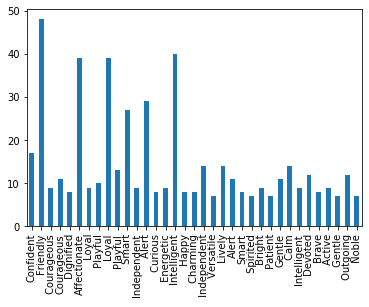

```python
good_personality_traits = [trait for trait in personality_traits if personality_traits.count(trait) > 6]

pd.Series(good_personality_traits).value_counts(sort=False).plot(kind='bar')
print("There are " + str(len(set(good_personality_traits))) + " personality traits that are used for at least 7 different dog breeds.")
```

From our graph we can see that there are still a significant, although much lesser, amount of personality traits that are used to describe at least 7 different dog breeds, 35 to be exact. This number was chosen arbitrarily so that all words could fit on the graph, since the vast majority of words were only used a few times, if not once. This further supports the ideas previously mentioned, which is that the vast majority of dog breeds are being unique described by specific personality traits, giving us powerful and expressive searching ability. This graph shows that many breeds do have some personality traits in common with each however, which is also a good thing since we want our user to have a variety among choices from a certain personality type to further narrow their query. Some notably common personality traits include "Friendly", occuring in nearly 50 different breeds, "Confident", "Affectionate", "Loyal", "Alert", "Intelligent", which are quite generic. Seeing as how most breeds have more than 3 personality traits, these are most likely additional traits that may not be as unique, but will help us when trying to identify dogs in vague or broad queries. Among the other "common" traits, there is a pretty even distribution. Overall, the temperament / personality traits data proves to be very insightful and potentially useful as it provides us to allow users to query dog breeds with both extreme narrowness and broad generality which should return accurate and relevant results.